# Árboles de decisión

## 4.4 Realizando hiperparámetro tunning

**R**

**Mostrar código**

```r
# Detectamos cuales son los parámetros del modelo que podemos realizar hiperparámeter tunning
modelLookup("rpart")
```

|  | model | parameter | label | forReg | forClass | probModel |
| --- | --- | --- | --- | --- | --- | --- |
| 1 | rpart | cp | Complexity Parameter | TRUE | TRUE | TRUE |

**Mostrar código**

```r
# Se especifica un rango de valores típicos para el hiperparámetro
tuneGrid <- expand.grid(cp = seq(0.01,0.05,0.01))
```

**Mostrar código**

```r
# se entrena el modelo
set.seed(1994)

model <- train(RENTA ~ .,
               data = rtrain,
               method = "rpart",
               metric = "Accuracy",
               trControl = trControl,
               tuneGrid = tuneGrid)

# Obtenemos la información del mejor modelo
model$bestTune
```

|  | cp |
| --- | --- |
| 1 | 0.01 |

**Mostrar código**

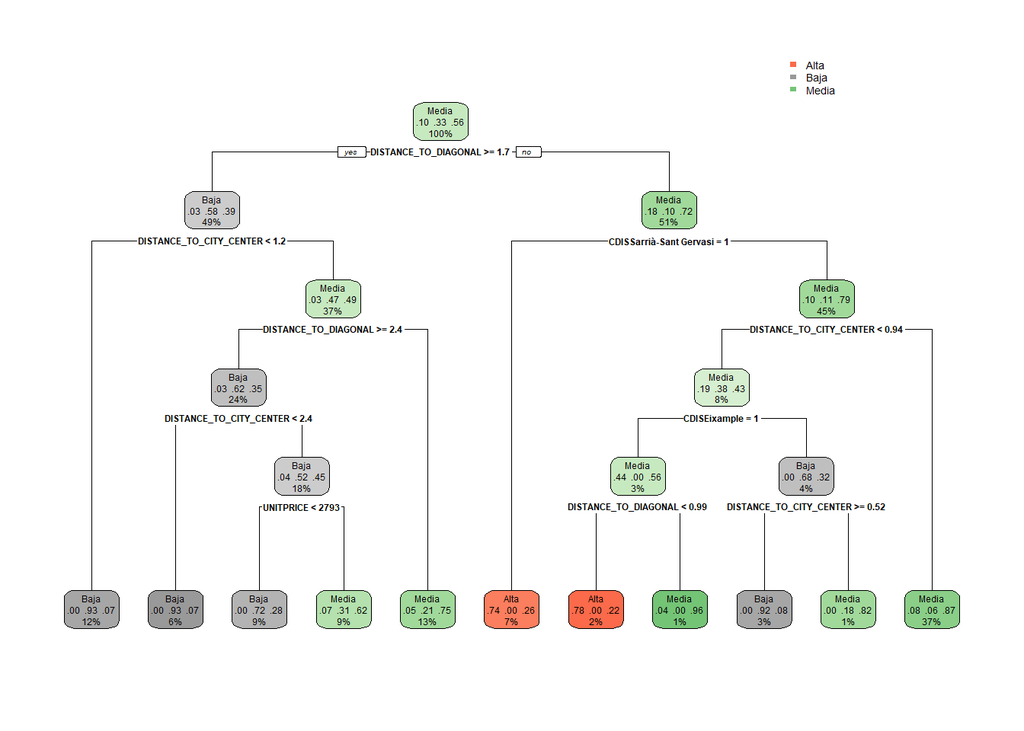

```r
# Gráfico del árbol obtenido
rpart.plot(model$finalModel)
```

**Python**

**Mostrar código**

```python
from sklearn.model_selection import GridSearchCV

# Definir rejilla de hiperparámetros
param_grid = {
    'max_depth': [None, 5, 10],
    'min_samples_split': [2, 5, 10],
    'min_samples_leaf': [1, 2, 4]
}

# Declaramos el modelo
model = DecisionTreeClassifier(random_state=1994)

# Configurar GridSearch con validación cruzada
grid_search = GridSearchCV(estimator=model, param_grid=param_grid, cv=10, scoring='accuracy', n_jobs=-1)

# Ajustar modelo
grid_search.fit(pyX_train, pyy_train)
```

```
GridSearchCV(cv=10, estimator=DecisionTreeClassifier(random_state=1994),
             n_jobs=-1,
             param_grid={'max_depth': [None, 5, 10],
                         'min_samples_leaf': [1, 2, 4],
                         'min_samples_split': [2, 5, 10]},
             scoring='accuracy')
```

**Mostrar código**

```python
# Mostrar mejores parámetros
print(f"Mejores parámetros: {grid_search.best_params_}")
```

```
Mejores parámetros: {'max_depth': None, 'min_samples_leaf': 1, 'min_samples_split': 2}
```

**Mostrar código**

```python
print(f"Mejor accuracy: {grid_search.best_score_:.4f}")
```

```
Mejor accuracy: 0.9071
```

**Mostrar código**

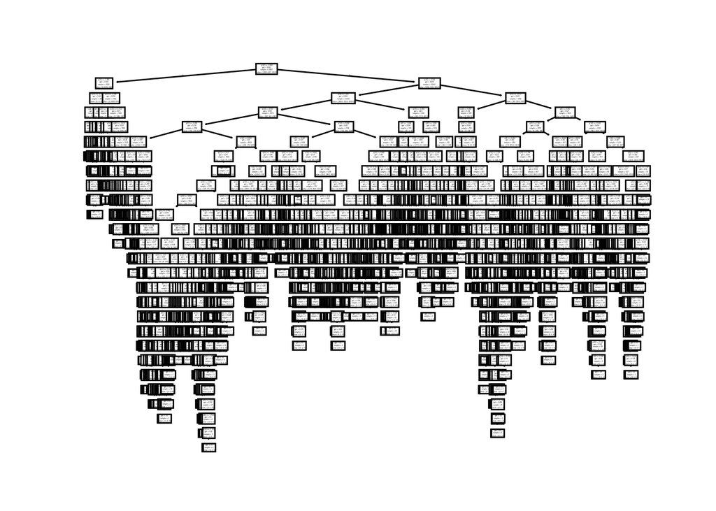

```python
from sklearn import tree
tree.plot_tree(grid_search.best_estimator_)
```

## 4.5 Como realizar poda de nuestro árbol

**R**

**Mostrar código**

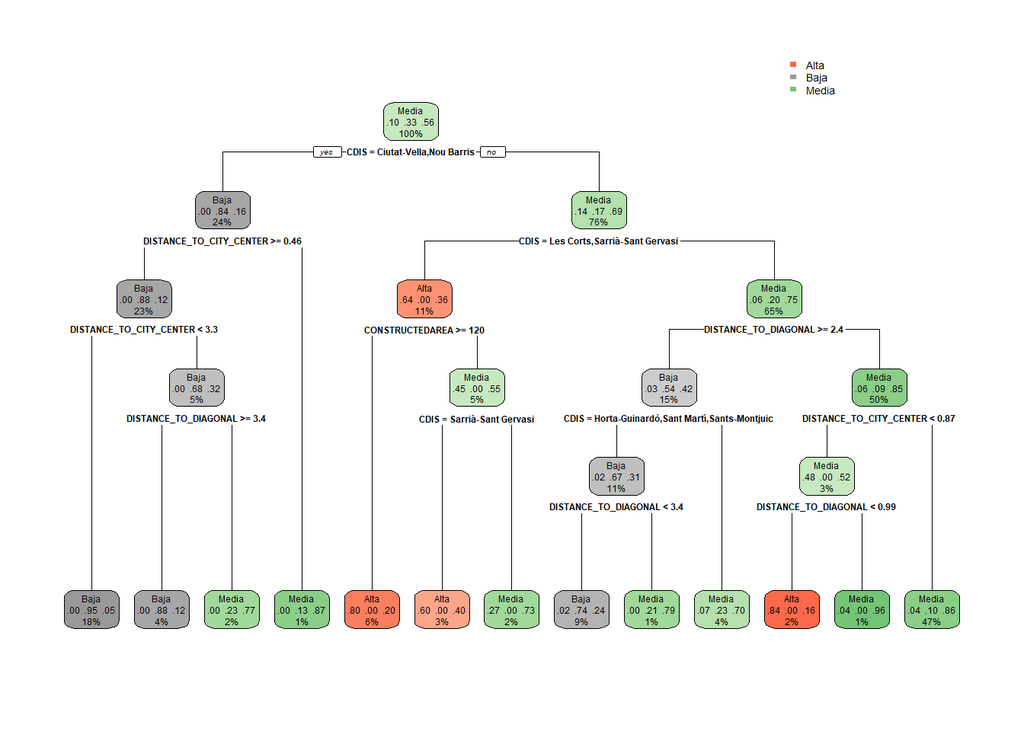

```r
# Con el objetivo de aumentar la generalidad del árbol y facilitar su interpretación,
# se procede a reducir su tamaño podándolo. Para ello se establece el criterio de
# que un nodo terminal tiene que tener, como mínimo, 50 observaciones.
set.seed(1994)
prunedtree <- rpart(RENTA ~ ., data = rtrain,
                    cp= 0.01, control = rpart.control(minbucket = 50))

rpart.plot(prunedtree)
```

**Python**

En Python, la poda de un árbol de decisión se puede realizar ajustando los hiperparámetros del árbol durante su creación. Estos hiperparámetros controlan el crecimiento del árbol y, por lo tanto, actúan como técnicas de poda preventiva o postpoda.

`scikit-learn` no implementa poda dinámica directa (como ocurre en algunos otros frameworks), pero puedes limitar el tamaño del árbol y evitar sobreajuste mediante los siguientes métodos.

### 4.5.1 Poda Preventiva (Pre-pruning)

**Poda preventiva** consiste en detener el crecimiento del árbol antes de que se haga demasiado grande. Esto se logra ajustando hiperparámetros como:

- `max_depth`: Profundidad máxima del árbol
- `min_samples_split`: Número mínimo de muestras necesarias para dividir un nodo.
- `min_samples_leaf`: Número mínimo de muestras necesarias en una hoja.
- `max_leaf_nodes`: Número máximo de nodos hoja en el árbol.

**Mostrar código**

```python
# Crear un árbol con poda preventiva
model = DecisionTreeClassifier(
    max_depth=3,              # Limitar la profundidad
    min_samples_split=10,     # Mínimo 10 muestras para dividir un nodo
    min_samples_leaf=5,       # Mínimo 5 muestras por hoja
    random_state=42
)

# Entrenar el modelo
model.fit(pyX_train, pyy_train)
```

```
DecisionTreeClassifier(max_depth=3, min_samples_leaf=5, min_samples_split=10,
                       random_state=42)
```

**Mostrar código**

```python
# Evaluar
print(f"Accuracy en entrenamiento: {model.score(pyX_train, pyy_train):.4f}")
```

```
Accuracy en entrenamiento: 0.7919
```

**Mostrar código**

```python
print(f"Accuracy en prueba: {model.score(pyX_test, pyy_test):.4f}")
```

```
Accuracy en prueba: 0.7932
```

**Mostrar código**

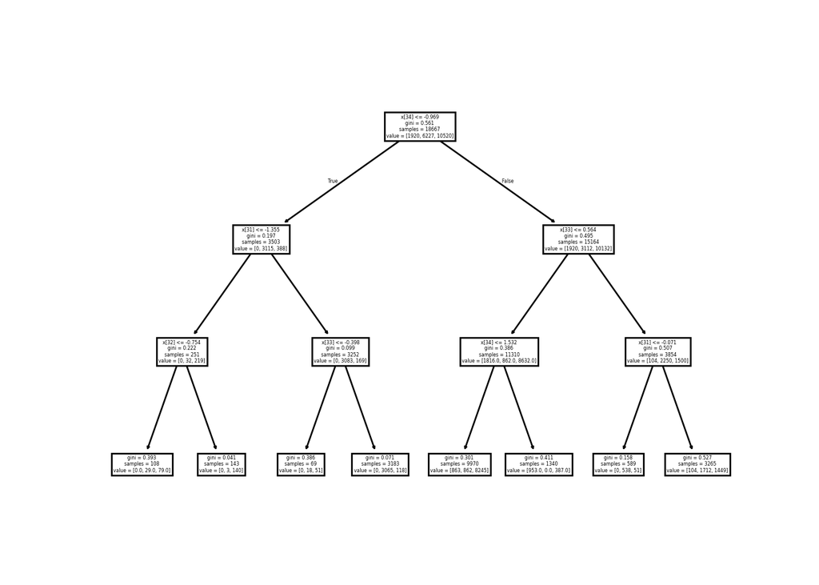

```python
# Graficamos el árbol podado
tree.plot_tree(model)
```

### 4.5.2 Poda Posterior (Post-Pruning) con `ccp_alpha`

Se puedes realizar poda posterior usando cost **complexity pruning**. Esto implica ajustar el parámetro `ccp_alpha` (el parámetro de complejidad de coste).

El árbol generará múltiples subárboles podados para diferentes valores de `ccp_alpha`, y tú puedes elegir el más adecuado evaluando su desempeño.

**Mostrar código**

```python
import matplotlib.pyplot as plt

# Crear un árbol sin poda
model = DecisionTreeClassifier(random_state=1994)
model.fit(pyX_train, pyy_train)
```

```
DecisionTreeClassifier(random_state=1994)
```

**Mostrar código**

```python
# Obtener valores de ccp_alpha
path = model.cost_complexity_pruning_path(pyX_train, pyy_train)
ccp_alphas = path.ccp_alphas
impurities = path.impurities

# Entrenar árboles para cada valor de ccp_alpha
models = []
for ccp_alpha in ccp_alphas:
    clf = DecisionTreeClassifier(random_state=42, ccp_alpha=ccp_alpha)
    clf.fit(pyX_train, pyy_train)
    models.append(clf)
```

```
DecisionTreeClassifier(ccp_alpha=np.float64(0.12113075107966081),
                       random_state=42)
```

**Mostrar código**

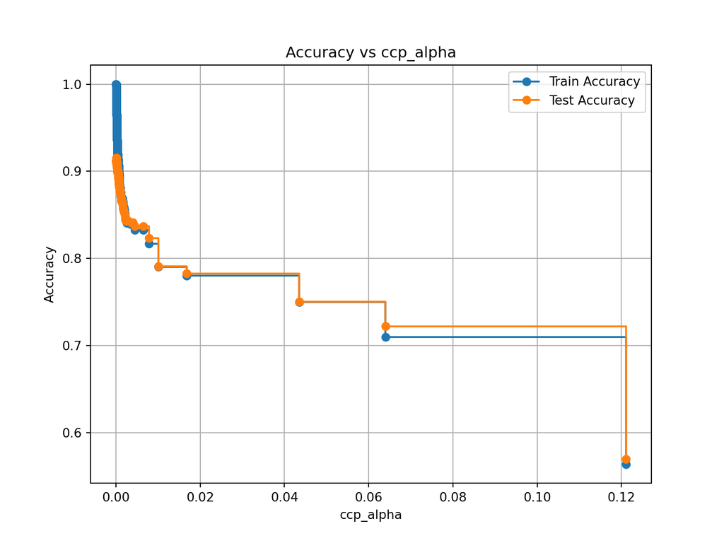

```python
# Evaluar desempeño
train_scores = [clf.score(pyX_train, pyy_train) for clf in models]
test_scores = [clf.score(pyX_test, pyy_test) for clf in models]

# Graficar resultados
plt.figure(figsize=(8, 6))
plt.plot(ccp_alphas, train_scores, marker='o', label="Train Accuracy", drawstyle="steps-post")
plt.plot(ccp_alphas, test_scores, marker='o', label="Test Accuracy", drawstyle="steps-post")
plt.xlabel("ccp_alpha")
plt.ylabel("Accuracy")
plt.title("Accuracy vs ccp_alpha")
plt.legend()
plt.grid()
plt.show()
```

Aquesta web està creada por Dante Conti y Sergi Ramírez, (c) 2026